# Cyclistic Data Review

Jonathon Briggs

2024-08-15

## Cyclistic Data Review

**Research Question:** How do annual members and casual riders use Cicylistic bikes differently?  
**Business Task:** Identify key differences between annual membership accounts and casual rider purchases, then compile actionable insights and hypotheses that can guide next steps in the market expansion process

### Data Sources

Cyclistic data was collected at the following [link](https://divvy-tripdata.s3.amazonaws.com/index.html)

Cyclistic Station Data was collect from 2 files * Divvy_Stations_2014-Q1Q2.xlsx  
* Divvy_Stations_2014-Q3Q4.csv

Cyclistic Trips data is collected from 4 files for a 12 month trend  
* Divvy_Trips_2014_Q1Q2.csv  
* Divvy_Trips_2014-Q3-07.csv  
* Divvy_Trips_2014-Q3-0809.csv  
* Divvy_Trips_2014-Q4.csv

All File Location references assume a working directory with **Start_Data** as an available sub folder with csv files

### Data Preparation: Station Data

This step is completed in excel due to small size of data set and easy of cleaning via xlookup before creating a combined csv file  
New file name is: *Divvy_Stations_Combined_Q1Q4.csv*

### Let’s install the required packages first

```r
#install.packages("tidyverse")
library(tidyverse)
#install.packages("shiny")
library(shiny)
library(lubridate)
```

### Cleaning of each table before combining

This step was not actually necessary, but some issues during the csv import caused some concern that was mitigated by double checking each of the data files before rbind was completed

```r
Trips_Q1Q2$starttime <- mdy_hm(Trips_Q1Q2$starttime,tz="UTC")
Trips_Q1Q2$stoptime <- mdy_hm(Trips_Q1Q2$stoptime,tz="UTC")

Trips_Q3_7$starttime <- mdy_hm(Trips_Q3_7$starttime,tz="UTC")
Trips_Q3_7$stoptime <- mdy_hm(Trips_Q3_7$stoptime,tz="UTC")

Trips_Q3_89$starttime <- mdy_hm(Trips_Q3_89$starttime,tz="UTC")
Trips_Q3_89$stoptime <- mdy_hm(Trips_Q3_89$stoptime,tz="UTC")

Trips_Q4$starttime <- mdy_hm(Trips_Q4$starttime,tz="UTC")
Trips_Q4$stoptime <- mdy_hm(Trips_Q4$stoptime,tz="UTC")
```

### Data validity checks

Before any serious exploration, we run a quick summary of the complete table to see if any data may be missing in a substantial way  
Missing fields in data set account for ~32% of data set, therefore should not use these fields for conclusions:  
* birthyear field has 791,216 NA values * gender field has 791,280 NA values

```r
#summary(trips_complete)
#ggplot(trips_complete,aes(x=from_station_name, fill=from_station_name)) + geom_bar() + geom_text(aes(label = after_stat(count)), stat = "count", vjust = 1.5, color = "white")

#dplyr::count(trips_complete, gender)
#dplyr::count(trips_complete, from_station_name)
#dplyr::count(trips_complete, to_station_name)
#dplyr::count(trips_complete, usertype)
#dplyr::count(trips_complete, bikeid)
#dplyr::count(trips_complete, birthyear)
#trips_complete %>% filter(is.na(birthyear) | is.na(gender))
```

### Additional fields construction

Now we will add 2 additional fields for the assessment: day_of_week and ride_length

```r
trips_complete$ride_length <- trips_complete$stoptime - trips_complete$starttime
trips_complete$day_of_week <- weekdays(trips_complete$starttime)
#head(trips_complete)
```

### Metrics of ride length field to expolore best path for further investigation

```r
#dplyr::count(trips_complete,ride_length, sort=TRUE) # Top 10: 6,7,5,8,9,10,4,11,12,13
#dplyr::count(trips_complete,ride_length > 300, sort=FALSE) # Finding the Outlier Range
#mean(trips_complete$ride_length) # 17.08 min
#min(trips_complete$ride_length) # 1 min
#max(trips_complete$ride_length) # 1,440 min
```

```r
#dplyr::count(trips_complete,day_of_week, sort=TRUE) # Daily averages fairly flat, Fri & Sat: ~15% / Mon & Thu & Sun ~14%, Tue & Wed ~13.5%
#mean(trips_complete$ride_length) # 17.08 min
#min(trips_complete$ride_length) # 1 min
#max(trips_complete$ride_length) # 1,440 min
```

### GGPlot for comparisons of ride volumes vs. days of week - using count data

Conclusion 1: Subscribers are significantly less active on the weekends  
Issue Found: Box Plotting is affected by outliers at extreme scale, will make modified trips_complete variable to combat the outlier issue

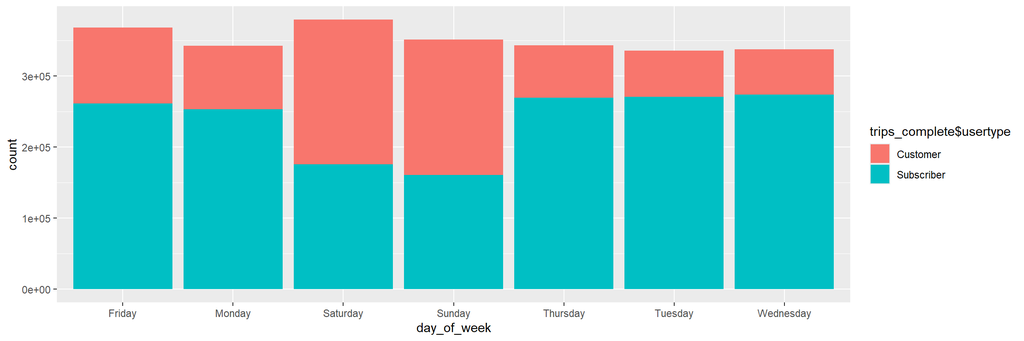

```r
#ggplot(trips_complete, aes(x=day_of_week)) + geom_bar() #Flat by day of week
ggplot(trips_complete, aes(x=day_of_week)) + geom_bar(aes(fill=trips_complete$usertype)) #Subscribers are significantly less active on the weekends
```

```r
#ggplot(trips_complete, aes(x=usertype, y=ride_length)) + geom_boxplot()
```

### GGPlot comparing ride volumes vs. days of week - using summary data

```r
bar_dow <- trips_complete %>%
  group_by(usertype, day_of_week) %>%
  count(usertype)
view(bar_dow)
bar_dow <- bar_dow %>% rename("user_counts" = 3)
```

### Some quick grouping in a separate DF to confirm the ratios of ride lengths

Using a mutate function with case_when to give some quick grouping justifying the charts below

```r
trips_comp_mod <- trips_complete |> mutate(Range = case_when(
  ride_length <= 60 ~ "A: 1-60 Minutes",
  ride_length > 60 & ride_length <= 300 ~ "B: 60-300 Minutes",
  ride_length > 60 ~ "C: 300-1500 Minutes",
  TRUE ~ "undetermined"
))

range_summary <- trips_comp_mod %>% group_by(Range) %>% count(usertype)
view(range_summary)
```

```r
#ggplot(trips_comp_mod,aes(x=Range)) + geom_bar()+
#  labs(x="Time Range in Minutes", y="Count of Rides", title="Rides Grouped by Time Ranges")
```

```
## Defaulting to continuous.
```

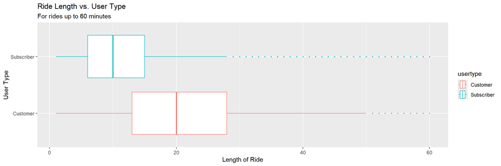

```r
trips_complete %>%
  filter(ride_length <= 60) %>%
  ggplot(aes(x=ride_length, y=usertype, color=usertype)) + geom_boxplot(outlier.size=.5) +
  labs(x="Length of Ride", y="User Type", title="Ride Length vs. User Type", subtitle="For rides up to 60 minutes")
```

```
## Defaulting to continuous.
```

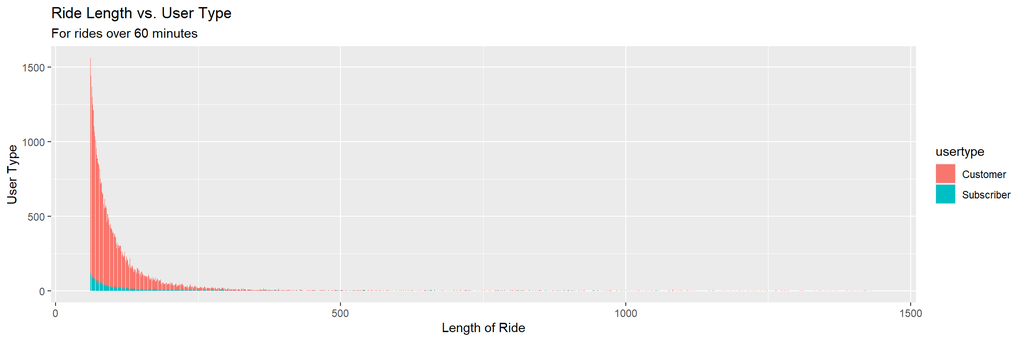

```r
trips_complete %>%
  filter(ride_length > 60) %>%
  ggplot(aes(x=ride_length,fill=usertype)) + geom_bar() +
  labs(x="Length of Ride", y="User Type", title="Ride Length vs. User Type", subtitle="For rides over 60 minutes")
```

### Now we will use the data to attempt to confirm active users per day based on rides Data is interesting, but not completely conclusive without making more assumptions about how to divide daily ride counts in a reasonable way

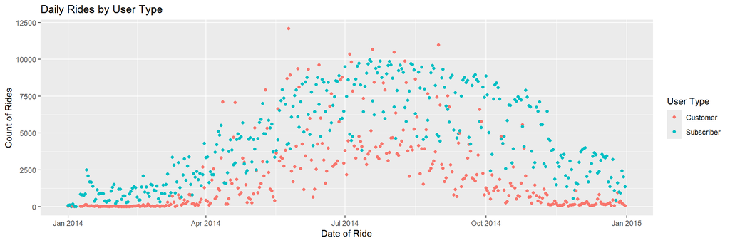

```r
trips_comp_mod2 <- trips_complete %>%
  mutate(start_date = as.Date(starttime))

trips_by_date <- trips_comp_mod2 %>%
  group_by(start_date) %>%
  count(usertype)

trips_by_date <- trips_by_date %>% rename("daily_trips" = 3)

ggplot(data = trips_by_date) + geom_point(mapping = aes(x=start_date, y=daily_trips, color=usertype)) +
  labs(x="Date of Ride", y="Count of Rides", title="Daily Rides by User Type") + guides(color = guide_legend(title = "User Type"))
```